# TP2_Berry

### Des graphiques : diagramme circulaire, en barre

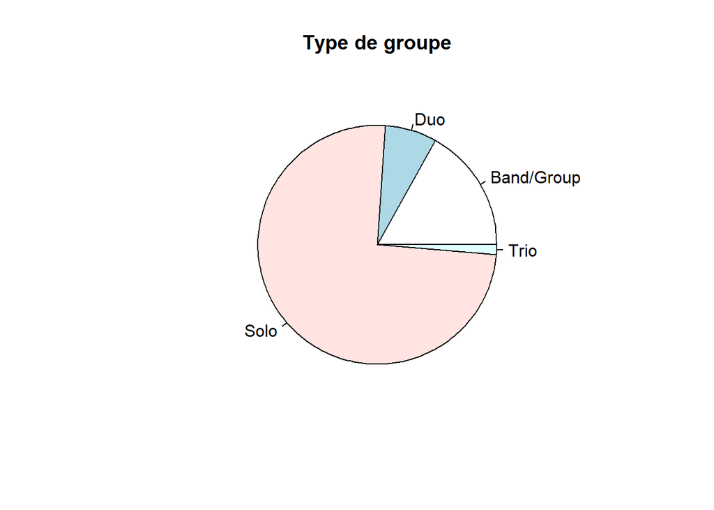

```r
pie(table(dat$Type))
title(main="Type de groupe")
```

La fonction pie nous permet d’avoir un visuel bien plus expressif de la repartition du type de groupe en general.

Pour exprimer les artistes de maniere graphique, on peut utiliser la fonction ‘barplot()’ qui va nous permettre de mettre sur l’axe des abscisses les 10 premiers artistes et sur les ordonnées le nombre d’occurence de leurs noms dans la base de données

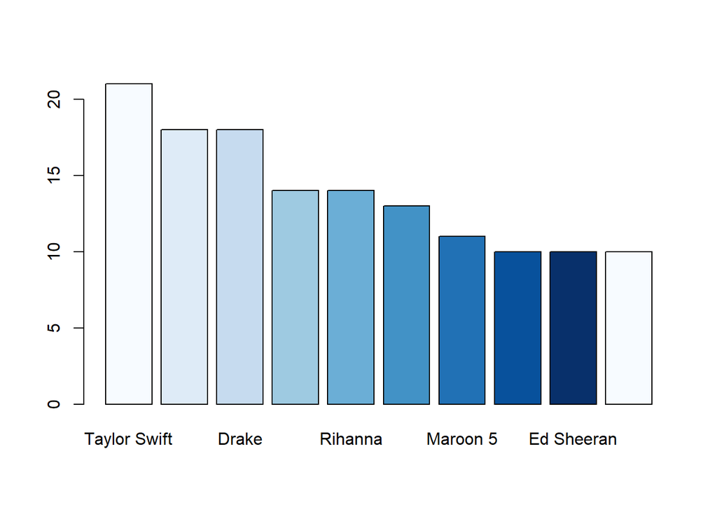

```r
TopArtist = head(sort(table(dat$artist), decreasing = TRUE), 10)
barplot(TopArtist,col = blues9)
```

# [ 5 ] Exportation de données

```r
write.table(dat,file="SpotifySongData.txt")
```